# Project: Investigate a Dataset - [TMDb movie data]

## Data Wrangling

> **Tip**: In this section of the report, you will load in the data, check for cleanliness, and then trim and clean your dataset for analysis. Make sure that you **document your data cleaning steps in mark-down cells precisely and justify your cleaning decisions.**

### General Properties

> **Tip**: You should *not* perform too many operations in each cell. Create cells freely to explore your data. One option that you can take with this project is to do a lot of explorations in an initial notebook. These don't have to be organized, but make sure you use enough comments to understand the purpose of each code cell. Then, after you're done with your analysis, create a duplicate notebook where you will trim the excess and organize your steps so that you have a flowing, cohesive report.

```python
df = pd.read_csv('tmdb-movies.csv')
df.describe()
```

|  | id | popularity | budget | revenue | runtime | vote_count | vote_average | release_year | budget_adj | revenue_adj |
| --- | --- | --- | --- | --- | --- | --- | --- | --- | --- | --- |
| count | 10866.000000 | 10866.000000 | 1.086600e+04 | 1.086600e+04 | 10866.000000 | 10866.000000 | 10866.000000 | 10866.000000 | 1.086600e+04 | 1.086600e+04 |
| mean | 66064.177434 | 0.646441 | 1.462570e+07 | 3.982332e+07 | 102.070863 | 217.389748 | 5.974922 | 2001.322658 | 1.755104e+07 | 5.136436e+07 |
| std | 92130.136561 | 1.000185 | 3.091321e+07 | 1.170035e+08 | 31.381405 | 575.619058 | 0.935142 | 12.812941 | 3.430616e+07 | 1.446325e+08 |
| min | 5.000000 | 0.000065 | 0.000000e+00 | 0.000000e+00 | 0.000000 | 10.000000 | 1.500000 | 1960.000000 | 0.000000e+00 | 0.000000e+00 |
| 25% | 10596.250000 | 0.207583 | 0.000000e+00 | 0.000000e+00 | 90.000000 | 17.000000 | 5.400000 | 1995.000000 | 0.000000e+00 | 0.000000e+00 |
| 50% | 20669.000000 | 0.383856 | 0.000000e+00 | 0.000000e+00 | 99.000000 | 38.000000 | 6.000000 | 2006.000000 | 0.000000e+00 | 0.000000e+00 |
| 75% | 75610.000000 | 0.713817 | 1.500000e+07 | 2.400000e+07 | 111.000000 | 145.750000 | 6.600000 | 2011.000000 | 2.085325e+07 | 3.369710e+07 |
| max | 417859.000000 | 32.985763 | 4.250000e+08 | 2.781506e+09 | 900.000000 | 9767.000000 | 9.200000 | 2015.000000 | 4.250000e+08 | 2.827124e+09 |

### Data Cleaning

> **Tip**: Make sure that you keep your reader informed on the steps that you are taking in your investigation. Follow every code cell, or every set of related code cells, with a markdown cell to describe to the reader what was found in the preceding cell(s). Try to make it so that the reader can then understand what they will be seeing in the following cell(s).

```python
df.isnull().sum()
```

```
id                         0
imdb_id                   10
popularity                 0
budget                     0
revenue                    0
original_title             0
cast                      76
homepage                7930
director                  44
tagline                 2824
keywords                1493
overview                   4
runtime                    0
genres                    23
production_companies    1030
release_date               0
vote_count                 0
vote_average               0
release_year               0
budget_adj                 0
revenue_adj                0
dtype: int64
```

```python
df.shape
```

```
(10866, 21)
```

```python
# After discussing the structure of the data and any problems that need to be
#   cleaned, perform those cleaning steps in the second part of this section.
df_v1 = df.drop(['homepage','tagline','imdb_id','overview','vote_count','revenue','budget'], axis = 1)
df_v1 = df_v1.dropna();
df_v1.drop_duplicates(inplace=True) # Now df_v1 is the new clean dataset
```

```python
df_v1.shape
```

```
(8666, 14)
```

```python
df_v1.head(3)
```

|  | id | popularity | original_title | cast | director | keywords | runtime | genres | production_companies | release_date | vote_average | release_year | budget_adj | revenue_adj |
| --- | --- | --- | --- | --- | --- | --- | --- | --- | --- | --- | --- | --- | --- | --- |
| 0 | 135397 | 32.985763 | Jurassic World | Chris Pratt\|Bryce Dallas Howard\|Irrfan Khan\|Vi... | Colin Trevorrow | monster\|dna\|tyrannosaurus rex\|velociraptor\|island | 124 | Action\|Adventure\|Science Fiction\|Thriller | Universal Studios\|Amblin Entertainment\|Legenda... | 6/9/15 | 6.5 | 2015 | 1.379999e+08 | 1.392446e+09 |
| 1 | 76341 | 28.419936 | Mad Max: Fury Road | Tom Hardy\|Charlize Theron\|Hugh Keays-Byrne\|Nic... | George Miller | future\|chase\|post-apocalyptic\|dystopia\|australia | 120 | Action\|Adventure\|Science Fiction\|Thriller | Village Roadshow Pictures\|Kennedy Miller Produ... | 5/13/15 | 7.1 | 2015 | 1.379999e+08 | 3.481613e+08 |
| 2 | 262500 | 13.112507 | Insurgent | Shailene Woodley\|Theo James\|Kate Winslet\|Ansel... | Robert Schwentke | based on novel\|revolution\|dystopia\|sequel\|dyst... | 119 | Adventure\|Science Fiction\|Thriller | Summit Entertainment\|Mandeville Films\|Red Wago... | 3/18/15 | 6.3 | 2015 | 1.012000e+08 | 2.716190e+08 |

```python
df_v1.describe()
```

|  | id | popularity | runtime | vote_average | release_year | budget_adj | revenue_adj |
| --- | --- | --- | --- | --- | --- | --- | --- |
| count | 8666.000000 | 8666.000000 | 8666.000000 | 8666.000000 | 8666.000000 | 8.666000e+03 | 8.666000e+03 |
| mean | 57003.179206 | 0.741937 | 103.815140 | 6.003612 | 2000.129818 | 2.130749e+07 | 6.362440e+07 |
| std | 86242.565745 | 1.087657 | 26.207186 | 0.893539 | 13.221278 | 3.710269e+07 | 1.592874e+08 |
| min | 5.000000 | 0.000188 | 0.000000 | 1.500000 | 1960.000000 | 0.000000e+00 | 0.000000e+00 |
| 25% | 9816.750000 | 0.249990 | 91.000000 | 5.500000 | 1993.000000 | 0.000000e+00 | 0.000000e+00 |
| 50% | 16216.500000 | 0.449377 | 100.000000 | 6.100000 | 2004.000000 | 2.130703e+06 | 1.891237e+05 |
| 75% | 54003.000000 | 0.842984 | 113.000000 | 6.600000 | 2011.000000 | 2.810466e+07 | 5.524857e+07 |
| max | 417859.000000 | 32.985763 | 705.000000 | 8.700000 | 2015.000000 | 4.250000e+08 | 2.827124e+09 |

```python
df_v1.isnull().sum().sum()
```

```
0
```

```python
df_v1.duplicated().sum()
```

```
0
```

```python
df_v1.shape
```

```
(8666, 14)
```

==> Now our data is clean form duplicates and null values and known as (df_v1).

## Exploratory Data Analysis

> **Tip**: Now that you've trimmed and cleaned your data, you're ready to move on to exploration. **Compute statistics** and **create visualizations** with the goal of addressing the research questions that you posed in the Introduction section. You should compute the relevant statistics throughout the analysis when an inference is made about the data. Note that at least two or more kinds of plots should be created as part of the exploration, and you must compare and show trends in the varied visualizations.

> **Tip**: - Investigate the stated question(s) from multiple angles. It is recommended that you be systematic with your approach. Look at one variable at a time, and then follow it up by looking at relationships between variables. You should explore at least three variables in relation to the primary question. This can be an exploratory relationship between three variables of interest, or looking at how two independent variables relate to a single dependent variable of interest. Lastly, you should perform both single-variable (1d) and multiple-variable (2d) explorations.

### Research Question 1 (Which genres are most popular from 2011 to 2015 ?)

```python
def split(ff):
    hf = ff[ff['genres'].str.contains('|')]
    df1 = hf
    df2 = hf
    df3 = hf
    df4 = hf
    df1.genres = df1.genres.apply(lambda x: x.split('|')[0] )
    df2.genres = df2.genres.apply(lambda x: x.split('|')[1] if len(x.split('|')) > 1 else x)
    df3.genres = df3.genres.apply(lambda x: x.split('|')[2] if len(x.split('|')) > 2 else x)
    df4.genres = df4.genres.apply(lambda x: x.split('|')[3] if len(x.split('|')) > 3 else x)
    df0 = df1.append([df2, df3, df4])
    return df0
```

```python
df0 = split(df_v1)
x = pd.DataFrame(df0.groupby("release_year")["genres"].value_counts())
x.rename(columns ={"genres":"count"},inplace=True)
x.reset_index(inplace=True)
```

```python
df0.shape
```

```
(34664, 14)
```

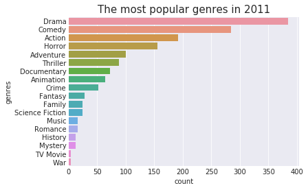

```python
sx = x[x["release_year"] == 2011]["genres"]
sy = x[x["release_year"] == 2011]["count"]
sns.barplot(sy,sx)
plt.title('The most popular genres in 2011', fontsize=15);
```

The most popular genres in 2011 is drama.

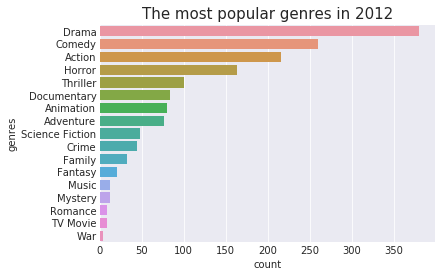

```python
sx = x[x["release_year"] == 2012]["genres"]
sy = x[x["release_year"] == 2012]["count"]
sns.barplot(sy,sx)
plt.title('The most popular genres in 2012', fontsize=15);
```

The most popular genres in 2012 is drama.

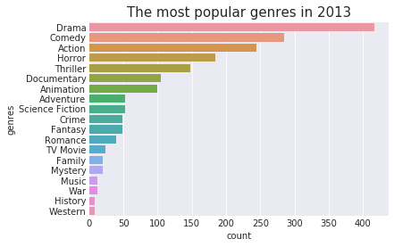

```python
sx = x[x["release_year"] == 2013]["genres"]
sy = x[x["release_year"] == 2013]["count"]
sns.barplot(sy,sx)
plt.title('The most popular genres in 2013', fontsize=15);
```

The most popular genres in 2013 is drama.

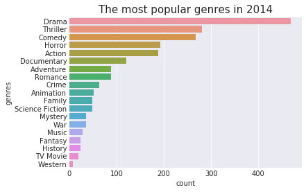

```python
sx = x[x["release_year"] == 2014]["genres"]
sy = x[x["release_year"] == 2014]["count"]
sns.barplot(sy,sx);
plt.title('The most popular genres in 2014', fontsize=15);
```

The most popular genres in 2014 is drama.

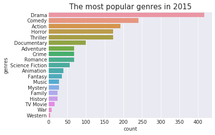

```python
sx = x[x["release_year"] == 2015]["genres"]
sy = x[x["release_year"] == 2015]["count"]
sns.barplot(sy,sx);
plt.title('The most popular genres in 2015', fontsize=15);
```

The most popular genres in 2015 is drama.

We notice that drama is the most popular genres in the years from 2011 to 2015.

### Research Question 2 ( What kinds of properties are associated with movies that have high revenues ?)

```python
mr = df_v1.sort_values('revenue_adj', ascending=False).head(20) # mr tends to 20 films with the biggest revenue.
mr.head()
```

|  | id | popularity | original_title | cast | director | keywords | runtime | genres | production_companies | release_date | vote_average | release_year | budget_adj | revenue_adj |
| --- | --- | --- | --- | --- | --- | --- | --- | --- | --- | --- | --- | --- | --- | --- |
| 1386 | 19995 | 9.432768 | Avatar | Sam Worthington\|Zoe Saldana\|Sigourney Weaver\|S... | James Cameron | culture clash\|future\|space war\|space colony\|so... | 162 | Action\|Adventure\|Fantasy\|Science Fiction | Ingenious Film Partners\|Twentieth Century Fox ... | 12/10/09 | 7.1 | 2009 | 2.408869e+08 | 2.827124e+09 |
| 1329 | 11 | 12.037933 | Star Wars | Mark Hamill\|Harrison Ford\|Carrie Fisher\|Peter ... | George Lucas | android\|galaxy\|hermit\|death star\|lightsaber | 121 | Adventure\|Action\|Science Fiction | Lucasfilm\|Twentieth Century Fox Film Corporation | 3/20/77 | 7.9 | 1977 | 3.957559e+07 | 2.789712e+09 |
| 5231 | 597 | 4.355219 | Titanic | Kate Winslet\|Leonardo DiCaprio\|Frances Fisher\|... | James Cameron | shipwreck\|iceberg\|ship\|panic\|titanic | 194 | Drama\|Romance\|Thriller | Paramount Pictures\|Twentieth Century Fox Film ... | 11/18/97 | 7.3 | 1997 | 2.716921e+08 | 2.506406e+09 |
| 10594 | 9552 | 2.010733 | The Exorcist | Linda Blair\|Max von Sydow\|Ellen Burstyn\|Jason ... | William Friedkin | exorcism\|holy water\|religion and supernatural\|... | 122 | Drama\|Horror\|Thriller | Warner Bros.\|Hoya Productions | 12/26/73 | 7.2 | 1973 | 3.928928e+07 | 2.167325e+09 |
| 9806 | 578 | 2.563191 | Jaws | Roy Scheider\|Robert Shaw\|Richard Dreyfuss\|Lorr... | Steven Spielberg | fishing\|atlantic ocean\|bathing\|shipwreck\|polic... | 124 | Horror\|Thriller\|Adventure | Universal Pictures\|Zanuck/Brown Productions | 6/18/75 | 7.3 | 1975 | 2.836275e+07 | 1.907006e+09 |

```python
mr_v1 = split(mr)
```

```python
dmr = pd.DataFrame(mr_v1.genres.value_counts())
dmr.reset_index(inplace=True)
dmr.rename(columns={"genres":"counts","index":"genres"}, inplace=True)
```

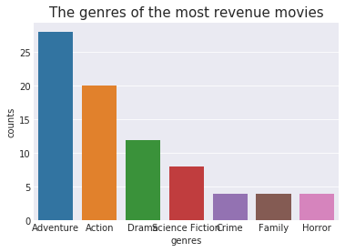

```python
dmx = dmr.genres
dmy = dmr.counts
sns.barplot(dmx, dmy);

plt.title('The genres of the most revenue movies', fontsize=15);
```

The plot tends to Adventure as the most popualr genre of the high revenue movies and the second genre is Action.

```python
dr = pd.DataFrame(mr.director.value_counts().head())
```

```python
dr.reset_index(inplace=True)
dr.rename(columns={"director":'counts', 'index':'director'}, inplace=True)
```

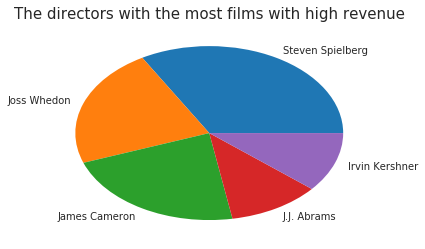

```python
plt.pie(dr.counts,labels=dr.director);
plt.title('The directors with the most films with high revenue', fontsize=15);
```

We found that the director with more high revenue movies is Steven Spielberg.

```python
High_revenue_budget = mr['budget_adj'].mean()
All_revenue_budget = df_v1['budget_adj'].mean()
```

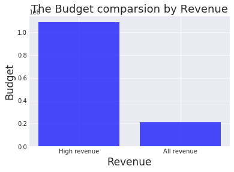

```python
plt.bar((1, 2), (High_revenue_budget, All_revenue_budget), tick_label=['High revenue', 'All revenue'], color="Blue", alpha =0.7);
plt.xlabel('Revenue', fontsize=17);
plt.ylabel('Budget', Fontsize=17);
plt.title('The Budget comparsion by Revenue', fontsize=18);
```

### Research Question 3 (Is the revenue of movies correlate with budget ?)

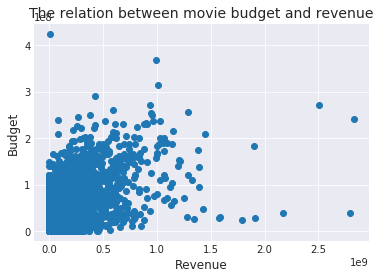

```python
plt.scatter(y=df_v1.budget_adj, x=df_v1.revenue_adj);
plt.title('The relation between movie budget and revenue',fontsize=14);
plt.xlabel('Revenue', fontsize=12);
plt.ylabel('Budget', fontsize=12);
```

We found that there is a positive correlation between revenue and budget.

### Research Question 4 (Is popularity correlate with budget ?)

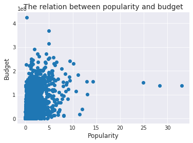

```python
plt.scatter(x=df_v1.popularity, y=df_v1.budget_adj);
plt.title('The relation between popularity and budget', fontsize= 14);
plt.xlabel('Popularity', fontsize=12);
plt.ylabel('Budget', fontsize=12);
```

There is a positive correlation between popularity and budget.

## Conclusions

[output not shown]

### Limitations

```
The most limitations for our analysis were the null values as we found some thousand null values in vital columns which is so big to our data size and can lead to some misunderstanding to our data.
```

## Submitting your Project

> **Tip**: Before you submit your project, you need to create a .html or .pdf version of this notebook in the workspace here. To do that, run the code cell below. If it worked correctly, you should get a return code of 0, and you should see the generated .html file in the workspace directory (click on the orange Jupyter icon in the upper left).

> **Tip**: Alternatively, you can download this report as .html via the **File** > **Download as** submenu, and then manually upload it into the workspace directory by clicking on the orange Jupyter icon in the upper left, then using the Upload button.

> **Tip**: Once you've done this, you can submit your project by clicking on the "Submit Project" button in the lower right here. This will create and submit a zip file with this .ipynb doc and the .html or .pdf version you created. Congratulations!

```python
from subprocess import call
call(['python', '-m', 'nbconvert', 'Investigate_a_Dataset.ipynb'])
```

```
0
```